# Lecture 10: Data mining and simple linear regression

ØKA2015 Applied Data Science, University of Inland Norway

Touseef Hameed

22 October 2026

# 1 What this document is

This is Lecture 10 as a written tutorial, in the same order as the script `lecture10_regression.R`. It follows Chapter 8 of *Business Analytics* (Camm et al.) and Chapter 5.7 of *Tidyverse Skills for Data Science* (Wright et al.). Read it after the lecture, or run it: open the `.Rmd` file in RStudio, press **Knit**, and this PDF is rebuilt on your computer.

In Lecture 7 you measured how strongly two variables move together with the correlation. In Lectures 8 and 9 you drew them with `ggplot2`. Today you build your first model: a straight line that predicts one variable from another.

# 2 Packages and the data

Two packages. Install each once per computer; running the install again does no harm.

```r
install.packages("tidyverse")
install.packages("broom")
```

Load them every session:

```r
library(tidyverse)
library(broom)
data(trees)
glimpse(trees)
```

```
#> Rows: 31
#> Columns: 3
#> $ Girth  <dbl> 8.3, 8.6, 8.8, 10.5, 10.7, 10.8, 11.0, 11.0, 11.1, 11.2, 11.3, …
#> $ Height <dbl> 70, 65, 63, 72, 81, 83, 66, 75, 80, 75, 79, 76, 76, 69, 75, 74,…
#> $ Volume <dbl> 10.3, 10.3, 10.2, 16.4, 18.8, 19.7, 15.6, 18.2, 22.6, 19.9, 24.…
```

`trees` comes with R itself. It describes 31 black cherry trees:

- `Girth` is the trunk **diameter** in inches, measured 4.5 feet above the ground. The name is misleading; R’s help page `?trees` says it is the diameter.
- `Height` is the height of the tree in feet.
- `Volume` is the volume of timber in cubic feet.

One inch is 2.54 cm and one foot is 0.30 m.

# 3 Data mining

**Data mining** is the use of software to find useful patterns in large amounts of data. It comes in two kinds:

- **Descriptive data mining**, also called *unsupervised learning*: there is no answer $y$ to predict. The aim is to find groups and patterns. Example: a shop groups its customers by what they buy.
- **Predictive data mining**, also called *supervised learning*: learn from past cases where the answer $y$ is known, then predict $y$ for new cases. Example: predict the price of a house from its size. When $y$ is a number, the task is called **regression**; when $y$ is a category, **classification**.

The variable we predict, $y$, is the *dependent variable*, *outcome* or *target*. The variable we predict it from, $x$, is the *independent variable*, *predictor* or *feature*. **Simple linear regression** uses one $x$ and a straight line.

## 3.1 The model

$$\mathbf{y = \alpha + \beta x +
\varepsilon}$$

- $\alpha$, the **intercept**: the value of $y$ when $x = 0$, where the line crosses the $y$-axis.
- $\beta$, the **slope**: rise over run, the change in $y$ divided by the change in $x$. When $x$ goes up by 1, $y$ goes up by $\beta$ on average. A slope of 0 means no linear relationship.
- $\varepsilon$, the **error term**: everything else that affects $y$, which the line does not capture. For a tree: age, soil, light.

Example: consumption $= \alpha + \beta \times$ income $+ \varepsilon$. Here $\beta$ is how much consumption rises when income rises by one unit.

$\alpha$ and $\beta$ are the true values for the whole population, which we never know. From a sample we estimate them; the estimates are written $\hat{\alpha}$ and $\hat{\beta}$ (“alpha-hat”, “beta-hat”), and the fitted line is $\hat{y} = \hat{\alpha} + \hat{\beta} x$.

# 4 A first look at two variables

The question for today: the diameter of a tree is easy to measure, but the height of a standing tree is not. Can we predict a tree’s height from its diameter? So $y$ is `Height` and $x$ is `Girth`.

Always look at the data before you fit anything:

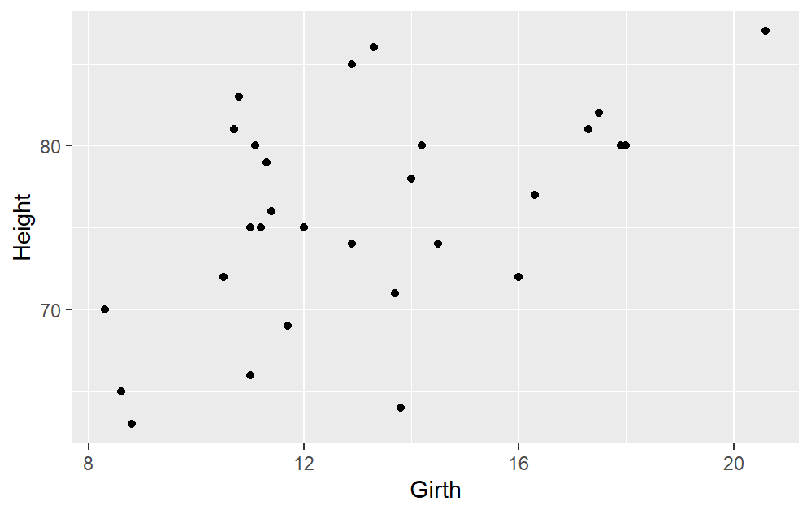

```r
ggplot(trees, aes(x = Girth, y = Height)) +
  geom_point()
```

```r
cor(trees$Girth, trees$Height)
```

```
#> [1] 0.5192801
```

The predictor goes on the horizontal axis and the outcome on the vertical axis. The points go up: thicker trees tend to be taller, but with much scatter. The correlation, $r = 0.52$, is positive and moderate.

# 5 Fitting the line

## 5.1 Least squares

A **residual** is actual minus fitted, $e = y - \hat{y}$: how far a point lies above or below the line. The **least squares method** picks the line with the smallest sum of squared residuals. The residuals are squared so that the ones above the line (positive) and below it (negative) do not cancel.

## 5.2 Fitting it in R

`lm()` fits a linear model. Read the formula `Height ~ Girth` as “height explained by girth”: the outcome on the left of the tilde, the predictor on the right. The general form is `lm(y ~ x, data = table)`.

```r
fit <- lm(Height ~ Girth, data = trees)
fit
```

```
#>
#> Call:
#> lm(formula = Height ~ Girth, data = trees)
#>
#> Coefficients:
#> (Intercept)        Girth
#>      62.031        1.054
```

The estimates replace $\alpha$ and $\beta$: **Height = 62.03 + 1.054 × Girth**.

- **Slope $\hat{\beta} = 1.054$.** One inch more diameter goes with 1.05 feet more height, on average. The unit of the slope is feet per inch.
- **Intercept $\hat{\alpha} = 62.03$.** The height the line gives for a diameter of 0. No tree is that thin (the diameters run from 8.3 to 20.6 inches), so it has no real meaning; it only positions the line.

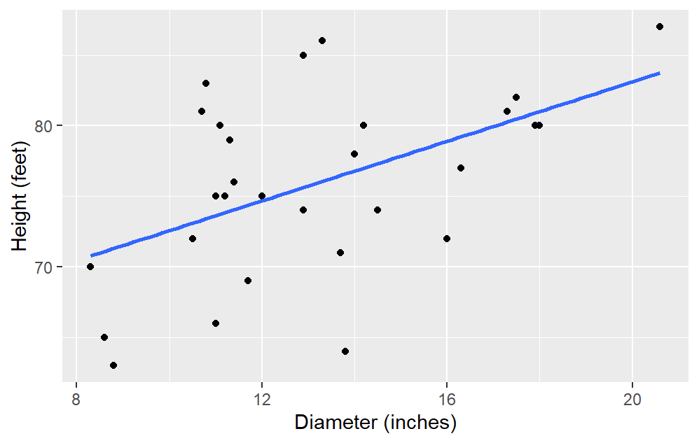

```r
ggplot(trees, aes(x = Girth, y = Height)) +
  geom_point() +
  geom_smooth(method = "lm", se = FALSE) +
  labs(x = "Diameter (inches)", y = "Height (feet)")
```

`geom_smooth(method = "lm")` runs the same `lm()` and draws the result. `se = FALSE` draws the line only. In RStudio you will also see the message `geom_smooth() using formula = 'y ~ x'`: that is information, not an error.

## 5.3 Fitted values, residuals and predictions

The **fitted value** of a tree is the point on the line at its diameter: the height the line says that tree should have. The residual is how far the real height is from it.

```r
trees_fit <- trees |>
  mutate(fitted   = fitted(fit),
         residual = residuals(fit))
head(trees_fit, 3)
```

```
#>   Girth Height Volume   fitted  residual
#> 1   8.3     70   10.3 70.78257 -0.782575
#> 2   8.6     65   10.3 71.09889 -6.098886
#> 3   8.8     63   10.2 71.30976 -8.309759
```

Tree 2 is 65 feet tall, but the line says 71.1 feet, so its residual is $-6.1$: it lies 6.1 feet below the line.

`predict()` gives the line’s answer for a new tree:

```r
predict(fit, newdata = tibble(Girth = 15))
```

```
#>        1
#> 77.84685
```

A tree 15 inches across is predicted to be 77.8 feet tall. Predict only inside the range of the data, here 8.3 to 20.6 inches. Outside that range is **extrapolation**: the data cannot show whether the line still holds there.

# 6 How sure are we about the estimates?

The 31 trees are a sample. Another 31 black cherry trees would give slightly different estimates. `summary()` reports how much they could change.

```r
summary(fit)
```

```
#>
#> Call:
#> lm(formula = Height ~ Girth, data = trees)
#>
#> Residuals:
#>      Min       1Q   Median       3Q      Max
#> -12.5816  -2.7686   0.3163   2.4728   9.9456
#>
#> Coefficients:
#>             Estimate Std. Error t value Pr(>|t|)
#> (Intercept)  62.0313     4.3833  14.152 1.49e-14 ***
#> Girth         1.0544     0.3222   3.272  0.00276 **
#> ---
#> Signif. codes:  0 '***' 0.001 '**' 0.01 '*' 0.05 '.' 0.1 ' ' 1
#>
#> Residual standard error: 5.538 on 29 degrees of freedom
#> Multiple R-squared:  0.2697, Adjusted R-squared:  0.2445
#> F-statistic: 10.71 on 1 and 29 DF,  p-value: 0.002758
```

In the `Coefficients` table, the row `Girth` holds four numbers about the slope, and the row `(Intercept)` the same four about the intercept:

- **Estimate, 1.0544**: the slope, the beta estimate.
- **Std. Error, 0.3222**: the **standard error**: how much the estimate would change from one sample to the next. A small standard error means a precise estimate. It gets smaller with more data and with points closer to the line.
- **t value, 3.272**: the estimate divided by its standard error. The slope lies 3.3 standard errors away from 0.
- **Pr(>|t|), 0.00276**: the **p-value**.

To read the p-value, suppose diameter and height had no linear relationship at all, so that the true slope were 0. The p-value is the chance of getting a slope at least this far from 0 in that case. Here it is 0.0028: fewer than 3 samples in 1,000.

**Decision rule:** a p-value below 0.05 makes the estimate **statistically significant**: we conclude that the true slope is not 0, so diameter does tell us something about height. The stars next to it say the same thing (`**` means p is between 0.001 and 0.01). The p-value does not say how big or how useful the slope is, and it is not the chance that our slope is wrong.

With the estimates, their standard errors and p-values, the fitted model reads:

Height = 62.03 + 1.054 × Girth, with standard errors (4.38) and (0.32), and p-values p < 0.001 and p = 0.003.

The same uncertainty can be drawn as a band around the line, the default of `geom_smooth()`:

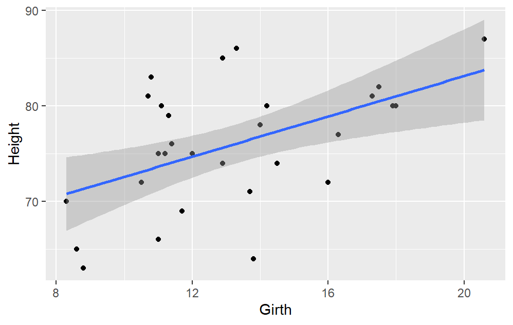

```r
ggplot(trees, aes(x = Girth, y = Height)) +
  geom_point() +
  geom_smooth(method = "lm")
```

The grey band shows where the true line plausibly runs. It is narrowest at the average diameter and widens towards the ends.

# 7 How good is the line?

## 7.1 R-squared

**R-squared** is the share of the variation in $y$ that the line explains, from 0 (nothing) to 1 (every point on the line). `summary(fit)` reports `Multiple R-squared: 0.2697`: 27% of the differences in height between the trees go with differences in diameter. The remaining 73% is unexplained: age, soil, light and other things, the error term. With one $x$, R-squared equals the correlation squared:

```r
cor(trees$Girth, trees$Height)^2
```

```
#> [1] 0.2696518
```

The **residual standard error**, 5.538 feet, is the typical distance of a tree from the line. It is not the same as the standard error of the slope.

## 7.2 The error term and the four conditions

The error term collects everything that affects $y$ apart from $x$. The standard error and the p-value are reliable when:

1. **Linearity**: the points follow a straight line, not a curve.
2. **Independence**: one observation does not affect another. Each tree is measured once.
3. **Equal spread**: the points are about as far from the line everywhere; no funnel.
4. **Normal residuals**: most residuals are small, few are large, roughly symmetric.

R draws four check plots for a fitted model:

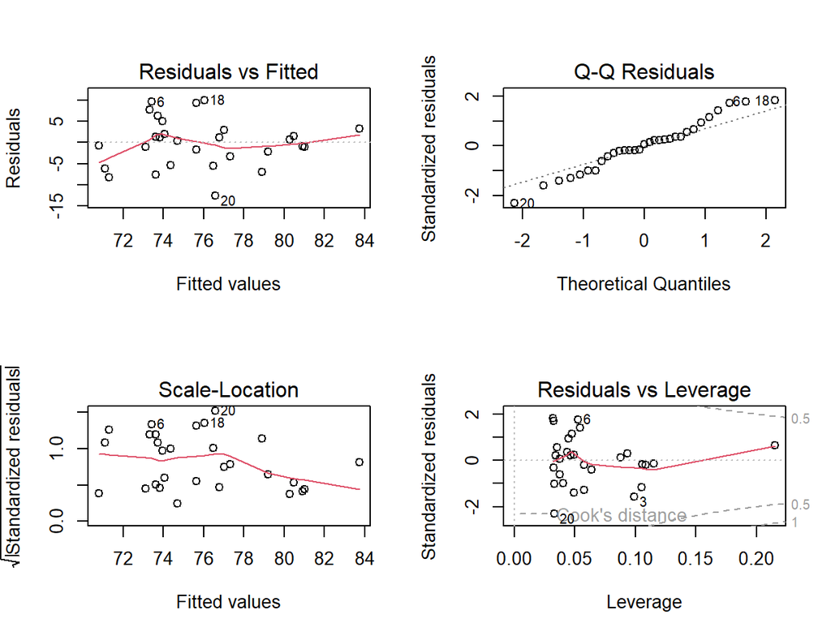

```r
par(mfrow = c(2, 2))
plot(fit)
```

```r
par(mfrow = c(1, 1))
```

`par(mfrow = c(2, 2))` puts the four plots in one window, 2 rows by 2 columns; the last line sets it back. Look for clear patterns; with 31 trees the red lines always wiggle a little.

- **Residuals vs Fitted**: look for a U or an arch. Here there is none: linearity holds.
- **Q-Q Residuals**: the points lie near the dotted line, so the residuals are roughly normal.
- **Scale-Location**: look for a clear rise or fall. Here the red line falls a little on the right. With 31 trees that is mild, so equal spread roughly holds.
- **Residuals vs Leverage**: no point lies beyond the dashed Cook’s distance lines, so no single tree drives the line.

## 7.3 The results as tables

The `broom` package gives the results of a model as tables (tibbles): `tidy()` for the coefficients, `glance()` for one row about the whole model, and `augment()` for one row per observation.

```r
tidy(fit)
```

```
#> # A tibble: 2 × 5
#>   term        estimate std.error statistic    p.value
#>   <chr>          <dbl>     <dbl>     <dbl>      <dbl>
#> 1 (Intercept)  62.031    4.3833    14.152  1.4930e-14
#> 2 Girth         1.0544   0.32222    3.2722 2.7578e- 3
```

```r
glance(fit)
```

```
#> # A tibble: 1 × 12
#>   r.squared adj.r.squared  sigma statistic   p.value    df  logLik    AIC    BIC
#>       <dbl>         <dbl>  <dbl>     <dbl>     <dbl> <dbl>   <dbl>  <dbl>  <dbl>
#> 1   0.26965       0.24447 5.5385    10.707 0.0027578     1 -96.017 198.03 202.34
#> # ℹ 3 more variables: deviance <dbl>, df.residual <int>, nobs <int>
```

```r
head(augment(fit), 3)
```

```
#> # A tibble: 3 × 8
#>   Height Girth .fitted   .resid     .hat .sigma   .cooksd .std.resid
#>    <dbl> <dbl>   <dbl>    <dbl>    <dbl>  <dbl>     <dbl>      <dbl>
#> 1     70   8.3  70.783 -0.78257 0.11514  5.6343 0.0014680   -0.15021
#> 2     65   8.6  71.099 -6.0989  0.10540  5.5032 0.079846    -1.1642
#> 3     63   8.8  71.310 -8.3098  0.099237 5.3882 0.13766     -1.5809
```

# 8 Correlation and causation

A regression measures how $x$ and $y$ move together. On its own it says nothing about cause and effect.

- **A confounder** is a third variable that drives both $x$ and $y$. Thicker trees tend to be taller, but a thicker trunk does not make a tree grow taller: older trees are both thicker and taller, so age drives both. Likewise, ice cream sales and sunburn cases rise and fall together because hot, sunny days drive both.
- **Reverse causation**: $y$ may drive $x$.
- **Coincidence**: among many variables, some pairs correlate by chance.

A cause is shown by a controlled experiment, where only $x$ is changed on purpose, not by a regression on observed data.

# 9 What you can do now

- say what predictive and descriptive data mining are
- fit a simple linear regression with `lm()` and draw it with `geom_smooth()`
- read the intercept and the slope in the units of the data, and predict
- read the standard error and the p-value, and apply the decision rule
- read R-squared, and check the conditions with the check plots
- explain why a strong relationship does not prove cause and effect

# 10 Sources

- Camm, J. D., Cochran, J. J., Fry, M. J. and Ohlmann, J. W. (2024). *Business Analytics* (5th ed.). Cengage. Ch. 1.3 and the introductions to Ch. 6 and Ch. 10 (data mining); Ch. 8 *Linear Regression*, sections 8.1 to 8.3 and 8.5.
- Wright, C., Ellis, S., Hicks, S. and Peng, R. (2021). *Tidyverse Skills for Data Science in R*, Ch. 5.7 *Linear Modeling*. https://jhudatascience.org/tidyversecourse/model.html
- The `trees` data: Ryan, T. A., Joiner, B. L. and Ryan, B. F. (1976). *The Minitab Student Handbook*. Duxbury. In R: `?trees`.
- Course repository: https://github.com/touseefhameed/oka2015-applied-data-science